# Assignment ### Part 2

Bradley Wallace

12/07/2020

**Question 1**

*Q1.a*

Ad_id with the least CPC that has the most impressions ad_id = 1121094

*Q1.b*

Campaign_id with highest CPM campaign_id = 936

**Question 2**

*Q2.a*

Refer Code and Plot below

*Q2.b*

Gender 0 Median ROAS = 1.5910899  
Gender 1 Median ROAS = 0.9215773

Gender 0 Mean ROAS = 3.141986  
Gender 1 Mean ROAS = 1.923027

```r
#load packages
suppressMessages(library(dplyr))
suppressMessages(library(ggplot2))
data_KAG <- read.csv("F:/Documents/KAG.csv", stringsAsFactors=FALSE)

## Q1.A ##
data_KAG %>%
  select(ad_id, Impressions, CPC) %>% #select relevant columns
  filter(CPC < 0.0001) %>% #from inspection there are a wide range of ads with 0 CPC
  arrange(desc(Impressions)) #descending order, showing max Impressions at top
```

```
##       ad_id Impressions CPC
## 1   1121094       24362   0
## 2   1121224       14289   0
## 3   1121252       11139   0
## 4   1121286       10991   0
## 5    776477        9982   0
## 6   1121375        9921   0
## 7   1121273        9370   0
## 8    776659        8817   0
## 9   1121854        8587   0
## 10  1121846        8350   0
## 11   776687        8022   0
## 12   776685        7745   0
## 13  1121359        7573   0
## 14   782130        7301   0
```

[output cut: 193 more lines]

```r
## Q1.B ##
data_KAG %>%
  select(campaign_id,Impressions,Spent) %>% #select relevant columns
  group_by(campaign_id) %>% #group by campaign
  summarise(CPM = (sum(Spent)/(sum(Impressions)/1000))) # in 1000s of views
```

```
## # A tibble: 3 x 2
##   campaign_id   CPM
##         <int> <dbl>
## 1         916 0.310
## 2         936 0.356
## 3        1178 0.272
```

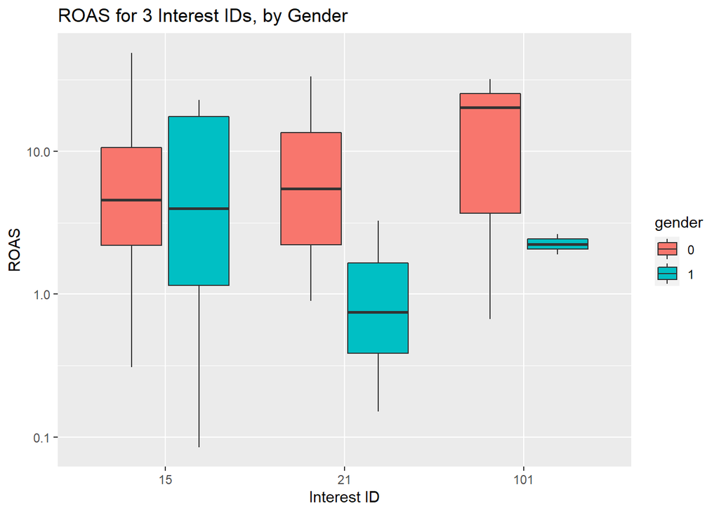

```r
## Q2 Data Preparation ##
data_KAG_ROAS <- data_KAG %>%
  filter(Spent>0) %>% #exclude costs = 0
  mutate(ROAS = (10*Total_Conversion + 50*Approved_Conversion)/Spent)

## Q2.A ##

#organize data for plotting
data_plot <- data_KAG_ROAS %>%
  filter(interest == c(15,21,101)) %>%
  group_by(gender)

data_plot$interest <- as.factor(data_plot$interest)#convert interest_id to factor, so that box plots are plotted fore each interest_id
data_plot$gender <- as.factor(data_plot$gender) #convert gender to factor, so that two box plots are plotted for each interest_id

plot_2a <- ggplot(data_plot, aes(x=interest, y=ROAS, fill=gender)) +
  scale_y_log10() +
  geom_boxplot() +
  labs(title = "ROAS for 3 Interest IDs, by Gender") +
  xlab("Interest ID") +
  ylab("ROAS")

plot_2a #plot the plot created above
```

```r
## Q2.B ##
data_KAG_ROAS %>%
  filter(campaign_id == 1178) %>%
  group_by(gender) %>%
  summarise(median_ROAS = median(ROAS))
```

```
## # A tibble: 2 x 2
##   gender median_ROAS
##    <int>       <dbl>
## 1      0       1.59
## 2      1       0.922
```

```r
data_KAG_ROAS %>%
  filter(campaign_id == 1178) %>%
  group_by(gender) %>%
  summarise(mean_ROAS = mean(ROAS))
```

```
## # A tibble: 2 x 2
##   gender mean_ROAS
##    <int>     <dbl>
## 1      0      3.14
## 2      1      1.92
```

**Question 3**

Refer Code and Scatterplot below

For a new individual with an internet usage <= 150 and age = 40, from this plot and general trends visualized, I would estimate that this new individual is more likely to be in the 1 category i.e. yes, someone who clicks on the ad.

That being, due to the encroachment of 0 category in this region of the plot, I would say there is still a chance this new individual could be a no (0), someone who does not click on the ad.

A K-Nearest Neighbour or SVM method of classification would in most cases return the predicted category as a yes (1), someone who clicks on the ad.

**Question 4**

Refer Code and Plot of Confusion Matrix below

**Question 5**

Based on the confusion matrix, FN occurrences count is 87.

Refer Code and ROC Plot below

```r
#load packages
suppressMessages(library(pROC))
suppressMessages(library(caret))

#suppressMessages(library(dplyr)) already loaded
#suppressMessages(library(ggplot2)) already loaded

#load data
data_ad <- read.csv("F:/Documents/advertising.csv", stringsAsFactors=FALSE, header=TRUE)
data_ad$Clicked.on.Ad <- as.factor(data_ad$Clicked.on.Ad) #convert to factor for plotting

#inspect data
head(data_ad)
```

```
##   Daily.Time.Spent.on.Site Age Area.Income Daily.Internet.Usage
## 1                    68.95  35    61833.90               256.09
## 2                    80.23  31    68441.85               193.77
## 3                    69.47  26    59785.94               236.50
## 4                    74.15  29    54806.18               245.89
## 5                    68.37  35    73889.99               225.58
## 6                    59.99  23    59761.56               226.74
##                           Ad.Topic.Line           City Male    Country
## 1    Cloned 5thgeneration orchestration    Wrightburgh    0    Tunisia
## 2    Monitored national standardization      West Jodi    1      Nauru
## 3      Organic bottom-line service-desk       Davidton    0 San Marino
## 4 Triple-buffered reciprocal time-frame West Terrifurt    1      Italy
## 5         Robust logistical utilization   South Manuel    0    Iceland
## 6       Sharable client-driven software      Jamieberg    1     Norway
##             Timestamp Clicked.on.Ad
## 1 2016-03-27 00:53:11             0
## 2 2016-04-04 01:39:02             0
## 3 2016-03-13 20:35:42             0
## 4 2016-01-10 02:31:19             0
## 5 2016-06-03 03:36:18             0
## 6 2016-05-19 14:30:17             0
```

```r
str(data_ad)
```

```
## 'data.frame':    1000 obs. of  10 variables:
##  $ Daily.Time.Spent.on.Site: num  69 80.2 69.5 74.2 68.4 ...
##  $ Age                     : int  35 31 26 29 35 23 33 48 30 20 ...
##  $ Area.Income             : num  61834 68442 59786 54806 73890 ...
##  $ Daily.Internet.Usage    : num  256 194 236 246 226 ...
##  $ Ad.Topic.Line           : chr  "Cloned 5thgeneration orchestration" "Monitored national standardization" "Organic bottom-line service-desk" "Triple-buffered reciprocal time-frame" ...
##  $ City                    : chr  "Wrightburgh" "West Jodi" "Davidton" "West Terrifurt" ...
##  $ Male                    : int  0 1 0 1 0 1 0 1 1 1 ...
##  $ Country                 : chr  "Tunisia" "Nauru" "San Marino" "Italy" ...
##  $ Timestamp               : chr  "2016-03-27 00:53:11" "2016-04-04 01:39:02" "2016-03-13 20:35:42" "2016-01-10 02:31:19" ...
##  $ Clicked.on.Ad           : Factor w/ 2 levels "0","1": 1 1 1 1 1 1 1 2 1 1 ...
```

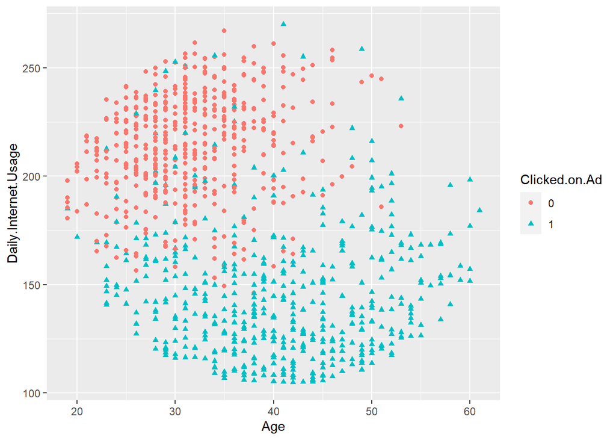

```r
## Q3 ##

plot_3 <- ggplot(data_ad,aes(x=Age, y=Daily.Internet.Usage, shape=Clicked.on.Ad, color=Clicked.on.Ad)) +
  geom_point()

plot_3 #plot the plot created above
```

```r
# For a new individual with an internet usage <= 150 and age = 40, from this plot and general trends visualized, I would estimate that this new individual is more likely to be in the 1 category i.e. yes, someone who clicks on the ad.

## Q4 ##

#create logistic regression model on full data set and test on full data set as instructed.
#this is not advisable due to introduction of bias, but has been done for simplicity's sake.

logit_model <- glm(Clicked.on.Ad ~ Daily.Time.Spent.on.Site + Age + Area.Income, data=data_ad, family="binomial")
data_ad_new <- data_ad %>%
  mutate(pred_prob = predict(logit_model, newdata=data_ad, type="response")) %>%
  mutate(pred_outcome = as.factor(ifelse(pred_prob > 0.8, 1, 0))) # using > 0.8 as the threshold value for Y=1 as instructed.

conf_matrix = confusionMatrix(data_ad_new$pred_outcome, data_ad_new$Clicked.on.Ad) #creat confusion matrix
conf_matrix #print output
```

```
## Confusion Matrix and Statistics
##
##           Reference
## Prediction   0   1
##          0 488  87
##          1  12 413
##
##                Accuracy : 0.901
##                  95% CI : (0.8808, 0.9188)
##     No Information Rate : 0.5
##     P-Value [Acc > NIR] : < 2.2e-16
##
##                   Kappa : 0.802
##
##  Mcnemar's Test P-Value : 1.028e-13
##
##             Sensitivity : 0.9760
##             Specificity : 0.8260
##          Pos Pred Value : 0.8487
##          Neg Pred Value : 0.9718
##              Prevalence : 0.5000
##          Detection Rate : 0.4880
##    Detection Prevalence : 0.5750
##       Balanced Accuracy : 0.9010
##
##        'Positive' Class : 0
##
```

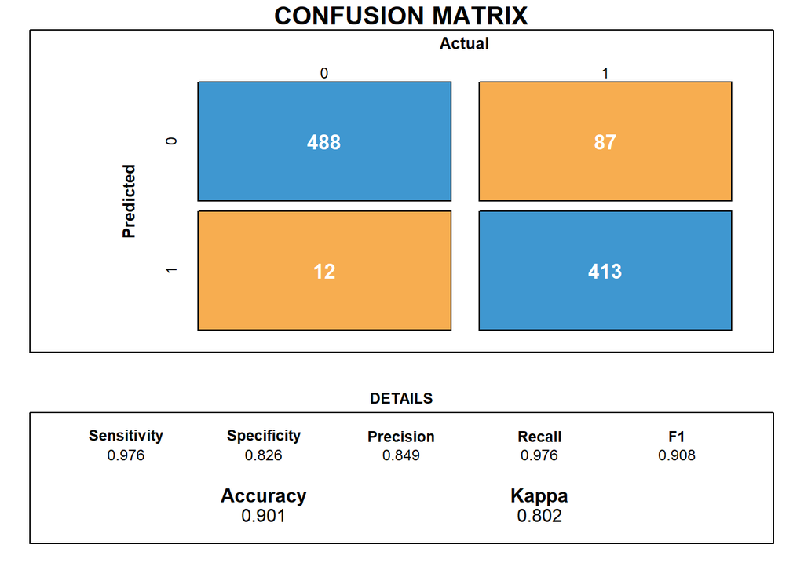

```r
#define draw_confusion_matrix function, from Week 10 TA session
draw_confusion_matrix <- function(cm) {

  layout(matrix(c(1,1,2)))
  par(mar=c(2,2,2,2))
  plot(c(100, 345), c(300, 450), type = "n", xlab="", ylab="", xaxt='n', yaxt='n')
  title('CONFUSION MATRIX', cex.main=2)

  # create the matrix
  rect(150, 430, 240, 370, col='#3F97D0')
  text(195, 435, '0', cex=1.2)
  rect(250, 430, 340, 370, col='#F7AD50')
  text(295, 435, '1', cex=1.2)
  text(125, 370, 'Predicted', cex=1.3, srt=90, font=2)
  text(245, 450, 'Actual', cex=1.3, font=2)
  rect(150, 305, 240, 365, col='#F7AD50')
  rect(250, 305, 340, 365, col='#3F97D0')
  text(140, 400, '0', cex=1.2, srt=90)
  text(140, 335, '1', cex=1.2, srt=90)

  # add in the cm results
  res <- as.numeric(cm$table)
  text(195, 400, res[1], cex=1.6, font=2, col='white')
  text(195, 335, res[2], cex=1.6, font=2, col='white')
  text(295, 400, res[3], cex=1.6, font=2, col='white')
  text(295, 335, res[4], cex=1.6, font=2, col='white')

  # add in the specifics
  plot(c(100, 0), c(100, 0), type = "n", xlab="", ylab="", main = "DETAILS", xaxt='n', yaxt='n')
  text(10, 85, names(cm$byClass[1]), cex=1.2, font=2)
  text(10, 70, round(as.numeric(cm$byClass[1]), 3), cex=1.2)
  text(30, 85, names(cm$byClass[2]), cex=1.2, font=2)
  text(30, 70, round(as.numeric(cm$byClass[2]), 3), cex=1.2)
  text(50, 85, names(cm$byClass[5]), cex=1.2, font=2)
  text(50, 70, round(as.numeric(cm$byClass[5]), 3), cex=1.2)
  text(70, 85, names(cm$byClass[6]), cex=1.2, font=2)
  text(70, 70, round(as.numeric(cm$byClass[6]), 3), cex=1.2)
  text(90, 85, names(cm$byClass[7]), cex=1.2, font=2)
  text(90, 70, round(as.numeric(cm$byClass[7]), 3), cex=1.2)

  # add in the accuracy information
  text(30, 35, names(cm$overall[1]), cex=1.5, font=2)
  text(30, 20, round(as.numeric(cm$overall[1]), 3), cex=1.4)
  text(70, 35, names(cm$overall[2]), cex=1.5, font=2)
  text(70, 20, round(as.numeric(cm$overall[2]), 3), cex=1.4)
}

draw_confusion_matrix(conf_matrix)
```

```r
## Q5 ##

#based on the confusion matrix, FN count = 87

roc_1 <- roc(as.integer(data_ad_new$pred_outcome), as.integer(data_ad_new$Clicked.on.Ad))
summary(roc_1)
```

```
##                    Length Class  Mode
## percent               1   -none- logical
## sensitivities         3   -none- numeric
## specificities         3   -none- numeric
## thresholds            3   -none- numeric
## direction             1   -none- character
## cases               425   -none- numeric
## controls            575   -none- numeric
## fun.sesp              1   -none- function
## auc                   1   auc    numeric
## call                  3   -none- call
## original.predictor 1000   -none- numeric
## original.response  1000   -none- numeric
## predictor          1000   -none- numeric
## response           1000   -none- numeric
## levels                2   -none- character
```

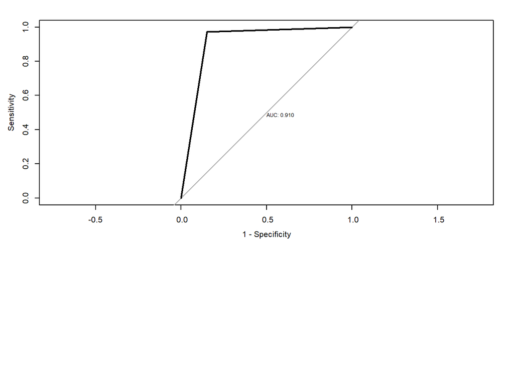

```r
plot(roc_1, legacy.axes=TRUE, print.auc=TRUE)
#legacy.axes logical to plot as 1 - Specificity (The False Positive Rate)
```

**Question 6**

*Q6.a*

Average wait time in queue: 7 minutes

*Q6.b*

Average number of customers waiting in queue with 6 servers: 2 people

**Question 7**

Refer Plot below

**Question 8**

*Q8.a*

Based on the Plot, 8 servers are required to have the average customer wait time in queue drop below 3 minutes.

*Q8.b*

In general, the chart is descreasing and resembles exponential decay: with every additional server, the average ‘wait in queue time’ decreases further, but at a rate of diminishing retruns. The service rate increases linearly at 14 customers per hour on average, thereby increasing the queueing systems capacity to deal with the variability in inter-arrival times and service times. However, as stated, there are diminishing returns on reducing the average ‘wait in queue’ times of customers for each additional server.

we know the arrival rate is 82 customers per hour and we have a minimum service rate with, 7 servers, of 98 customers per hour (7 x 14 customers per hour). The service rate increases linearly (although not shown explicitly on the plot) with each additional server and Understandably, even with this margin, the utilization of the system is somewhat high at 83.7% with 7 servers. Therefore, we should expect some waiting in response to the variability in the inter-arrival times and the service times (different personnel work faster or slower depending on a multitude of factors). This is why the average wait time for 7 servers is a 3 minutes and non-zero.

I would say a reasonably optimal selection of servers is approx. 11 to 14 servers. After this region, the benefit of adding another server is marginal. I would not recommend having more than 15 servers for the given arrival rate based on the plot.

The average wait time will approach zero (0) as we add more and more servers, to infinity.

The restaurant should consider the costs of servers vs. delay costs against profits to further optimize how many servers they should employ and what average wait time is reasonable for customers.

```r
#load package
suppressMessages(library(queueing))

#based on Question Description
lambda = 62 #customers per hour
mu = 70 #customers per hour

## Q6.a ##
rho = lambda/mu
Ls = lambda/(mu-lambda)
Lq = rho*Ls
Ws = Ls/lambda
Wq = Lq/lambda
print(paste0("Average wait time in queue: ", round(Wq*60, digits=0), " minutes.")) #round to nearest integer
```

```
## [1] "Average wait time in queue: 7 minutes."
```

```r
## Q6.b ##
mu_new = 84 #customers per hour with 6 servers
rho_new = lambda/mu_new
Ls_new = lambda/(mu_new-lambda)
Lq_new = rho_new*Ls_new
Ws_new = Ls_new/lambda
Wq_new = Lq_new/lambda
print(paste0("Average number of customers waiting in queue with 6 servers: ", round(Lq_new, digits=0), " person(s).")) #round to nearest integer
```

```
## [1] "Average number of customers waiting in queue with 6 servers: 2 person(s)."
```

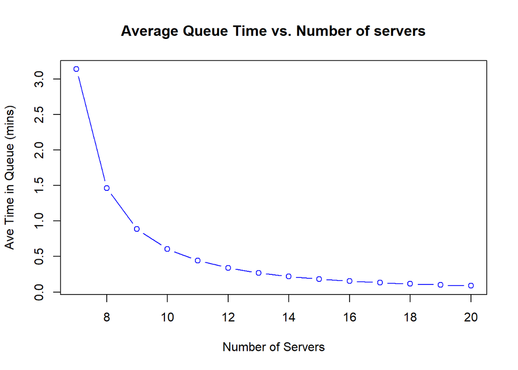

```r
## Q7 ##

#create a dataframe from scratch
number_of_servers <- c(7:20)
arrival_rate <- rep(82, length(number_of_servers))
data_queue <- data.frame(number_of_servers, arrival_rate)

data_queue <- data_queue %>%
  mutate(service_rate = 14*number_of_servers) %>%
  mutate(utilization = arrival_rate/service_rate) %>%
  mutate(L_service = arrival_rate/(service_rate - arrival_rate)) %>%
  mutate(L_queue = L_service*utilization) %>%
  mutate(W_service = 60*L_service/arrival_rate) %>% #in minutes
  mutate(W_queue = 60*L_queue/arrival_rate) #in minutes

plot(data_queue$number_of_servers, data_queue$W_queue,
     main="Average Queue Time vs. Number of servers",
     ylab="Ave Time in Queue (mins)",
     xlab="Number of Servers",
     type="b", #both points and a line
     col="blue")
```

```r
## Q8.a ##

#it appears that at least 8 servers are required for the ave. wait time to drop below 3 minutes
#check answer with MM1 model
input_mm1 <- NewInput.MM1(lambda=82,mu=14*8)
output_mm1 <- QueueingModel(input_mm1)
Report(output_mm1)
```

```
## The inputs of the M/M/1 model are:
## lambda: 82, mu: 112, n: 0
##
## The outputs of the M/M/1 model are:
##
## The probability (p0, p1, ..., pn) of the n = 0 clients in the system are:
## 0.2678571
## The traffic intensity is: 0.732142857142857
## The server use is: 0.732142857142857
## The mean number of clients in the system is: 2.73333333333333
## The mean number of clients in the queue is: 2.00119047619048
## The mean number of clients in the server is: 0.732142857142857
## The mean time spend in the system is: 0.0333333333333333
## The mean time spend in the queue is: 0.0244047619047619
## The mean time spend in the server is: 0.00892857142857143
## The mean time spend in the queue when there is queue is: 0.0333333333333333
## The throughput is: 82
```

```r
print(paste0("Average wait time in queue for 8 servers: ", round(60*output_mm1$Wq, digits=1), " minutes."))
```

```
## [1] "Average wait time in queue for 8 servers: 1.5 minutes."
```